# R-workshop

April 14, 2018

## Great resources

- [R for data science](http://r4ds.had.co.nz/): workflow, dplyr and ggplot basics
- [Stat 545](http://stat545.com/topics.html): Fantastic tutorials related to data exploration and analysis.
- [Advanced R](http://adv-r.had.co.nz/): data structure, writing better functions, R programming in general
- [Sytle guide](http://style.tidyverse.org/): write organized, readable code!

## Install packages

- Use command `install.packages("package-name")` (Don’t forget the quotes!)
- We will use the package collection [`tidyverse`](https://www.tidyverse.org/packages)
- `tidyvserse` includes
  - [ggplot](http://ggplot2.tidyverse.org/)
  - [dplyr](http://dplyr.tidyverse.org/)
- Load packages using `library(package-name)` (No quotes!)

## Some quick tips

- `<-` assignment operator (Alt/Option -)
- Ctrl + Enter to send line to console (you can highlight multiple lines)
- Ctrl + Shift + Enter runs the entire script
- Many more ways to send code, see: Rstudio menu > code
- Remember to use **tab completion**!
- Get help using `?functionName` or `??partialFunctionName`
- Other keyboard short cuts: Rstudio menu > Tools > keyboard

## Importing data

- Excel files: use the package `readxl`
- Various `read_...` functions

## Quick exploration

- What type of data do we have?
- Categorical, numerical, boolean, character

## Exploration

```r
# Import data set
bio_df <- readxl::read_xlsx('data/SSMI Data Sheet Spray Trial 1.xlsx')

# Taking a quick look at our data is easy
bio_df
View(bio_df)
```

## Exploration

```
## # A tibble: 320 x 10
##    Population Cage_Number Treatment   Day Mating_status Sex   Death
##    <chr>            <dbl> <chr>     <dbl> <chr>         <chr> <dbl>
##  1 H3                  1. Control      2. Virgin        F        0.
##  2 H3                  1. Control      3. Virgin        F        0.
##  3 H3                  1. Control      4. Virgin        F        0.
##  4 H3                  1. Control      5. Virgin        F        0.
##  5 H3                  1. Control      6. Virgin        F        0.
##  6 H3                  1. Control      7. Virgin        F        0.
##  7 H3                  1. Control      8. Virgin        F        0.
##  8 H3                  1. Control      9. Virgin        F        0.
##  9 H3                  1. Control     10. Virgin        F        0.
## 10 H3                  1. Control     11. Virgin        F        0.
## # ... with 310 more rows, and 3 more variables: Survival <dbl>,
## #   Percent_survival <dbl>, Eggs <chr>
```

## dplyr basics

- The [pipe](http://r4ds.had.co.nz/pipes.html) %>% (Ctrl + Shift + M)
- Pick observations by their values `filter()`.
- Reorder the rows `arrange()`.
- Pick variables by their names `select()`.
- Create new variables with functions of existing variables `mutate()`.
- Collapse many values down to a single summary `summarise()`.

## Selecting columns

```r
# Selecting columns
bio_df %>%
  select(Mating_status:Eggs) %>%
  head()
```

```
## # A tibble: 6 x 6
##   Mating_status Sex   Death Survival Percent_survival Eggs
##   <chr>         <chr> <dbl>    <dbl>            <dbl> <chr>
## 1 Virgin        F        0.      60.             100. 602
## 2 Virgin        F        0.      60.             100. 686
## 3 Virgin        F        0.      60.             100. 370
## 4 Virgin        F        0.      60.             100. 326
## 5 Virgin        F        0.      60.             100. 232
## 6 Virgin        F        0.      60.             100. 445
```

## Filtering

```r
# Filtering
bio_df %>%
  filter(Sex == "F")
```

```
## # A tibble: 160 x 10
##    Population Cage_Number Treatment   Day Mating_status Sex   Death
##    <chr>            <dbl> <chr>     <dbl> <chr>         <chr> <dbl>
##  1 H3                  1. Control      2. Virgin        F        0.
##  2 H3                  1. Control      3. Virgin        F        0.
##  3 H3                  1. Control      4. Virgin        F        0.
##  4 H3                  1. Control      5. Virgin        F        0.
##  5 H3                  1. Control      6. Virgin        F        0.
##  6 H3                  1. Control      7. Virgin        F        0.
##  7 H3                  1. Control      8. Virgin        F        0.
##  8 H3                  1. Control      9. Virgin        F        0.
##  9 H3                  1. Control     10. Virgin        F        0.
## 10 H3                  1. Control     11. Virgin        F        0.
## # ... with 150 more rows, and 3 more variables: Survival <dbl>,
## #   Percent_survival <dbl>, Eggs <chr>
```

- [List of logic operators](https://www.statmethods.net/management/operators.html)

## Grouping and summarize

```r
bio_df %>%
  select(Mating_status, Survival) %>%
  group_by(Mating_status) %>%
  summarize(mean_sur = mean(Survival))
```

```
## # A tibble: 3 x 2
##   Mating_status mean_sur
##   <chr>            <dbl>
## 1 Cohabit           24.6
## 2 Mated             43.4
## 3 Virgin            48.3
```

## Factors

Read more about factors

```r
sex_levels <- c("M", "F")
factor(bio_df$Sex, sex_levels)
```

```
##   [1] F F F F F F F F F F F F F F F F F F F F M M M M M M M M M M M M M M M
##  [36] M M M M M F F F F F F F F F F F F F F F F F F F F M M M M M M M M M M
##  [71] M M M M M M M M M M M M M M M M M M M M M M M M M M M M M M F F F F F
## [106] F F F F F F F F F F F F F F F M M M M M M M M M M M M M M M M M M M M
## [141] F F F F F F F F F F F F F F F F F F F F F F F F F F F F F F F F F F F
## [176] F F F F F M M M M M M M M M M M M M M M M M M M M F F F F F F F F F F
## [211] F F F F F F F F F F M M M M M M M M M M M M M M M M M M M M M M M M M
## [246] M M M M M M M M M M M M M M M F F F F F F F F F F F F F F F F F F F F
## [281] M M M M M M M M M M M M M M M M M M M M F F F F F F F F F F F F F F F
## [316] F F F F F
## Levels: M F
```

## Factors

```r
# Make sure the data is in a useable form
bio_df <- bio_df %>%
  mutate(Sex = factor(Sex)) %>%
  mutate(Population = factor(Population)) %>%
  mutate(Cage_Number = factor(Cage_Number)) %>%
  mutate(Treatment = factor(Treatment)) %>%
  mutate(Mating_status = factor(Mating_status)) %>%
  mutate(Eggs = as.numeric(Eggs))

head(bio_df)
```

```
## # A tibble: 6 x 10
##   Population Cage_Number Treatment   Day Mating_status Sex   Death
##   <fct>      <fct>       <fct>     <dbl> <fct>         <fct> <dbl>
## 1 H3         1           Control      2. Virgin        F        0.
## 2 H3         1           Control      3. Virgin        F        0.
## 3 H3         1           Control      4. Virgin        F        0.
## 4 H3         1           Control      5. Virgin        F        0.
## 5 H3         1           Control      6. Virgin        F        0.
## 6 H3         1           Control      7. Virgin        F        0.
## # ... with 3 more variables: Survival <dbl>, Percent_survival <dbl>,
## #   Eggs <dbl>
```

## Plotting

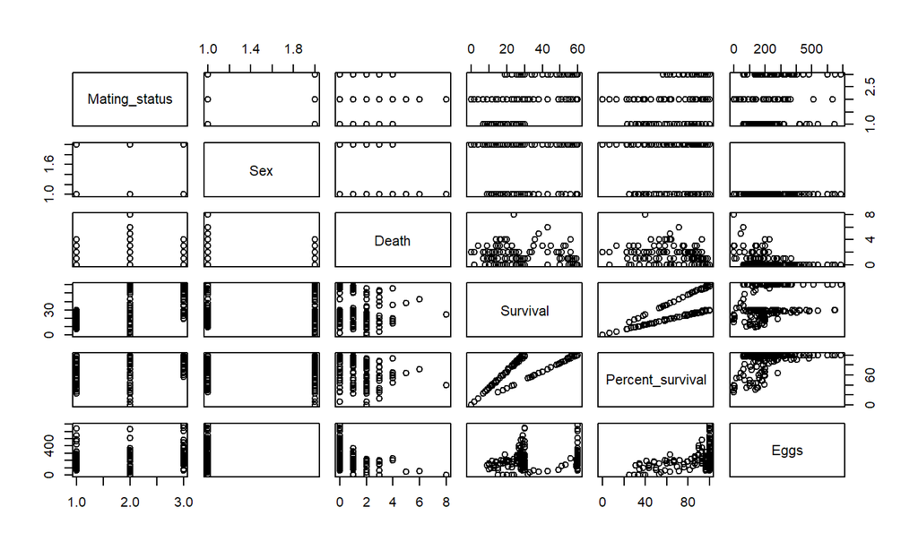

```r
# Scatter plot matrix
plot(bio_df[, 5:10])
```

## Box plot

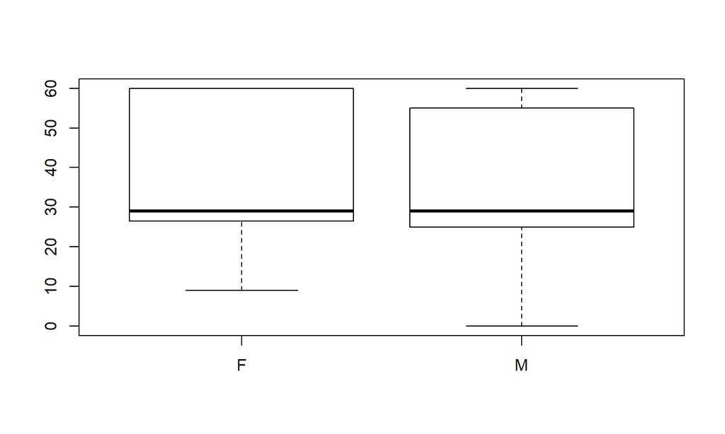

```r
# Scatter plot matrix
plot(x = bio_df$Sex, y = bio_df$Survival)
```

## ggplot

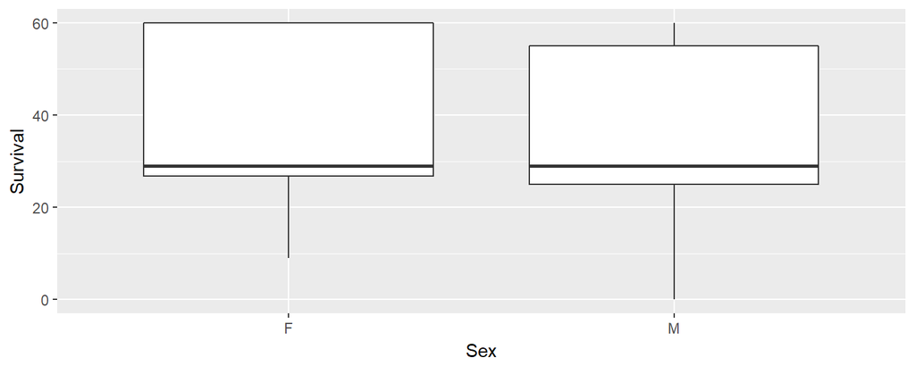

```r
bio_df %>% ggplot(aes(x = Sex, y = Survival)) +
  geom_boxplot()
```

- Note ggplot grammar is `ggplot()` **+** `geom_somethingsomething()`. This happened due to historical reasons.

## Why ggplot

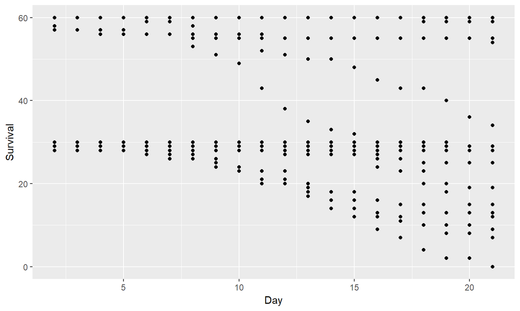

```r
dayplot <- bio_df %>% ggplot(aes(x = Day, y = Survival))

dayplot + geom_point()
```

## Why ggplot

```r
# Data is already mapped, adding extra elements
dayplot +
  geom_point(aes(color = Mating_status))
```

[output not shown]

## Why ggplot

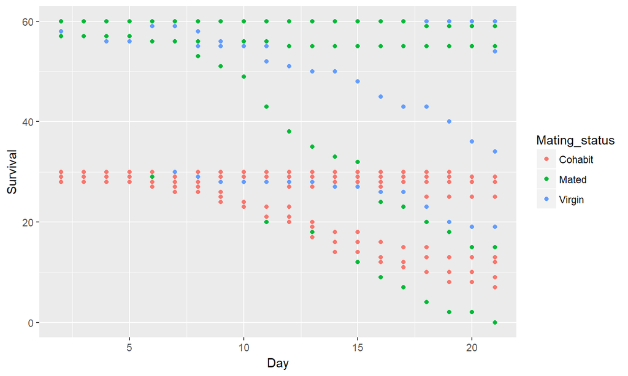

```r
dayplot +
  geom_point(aes(color = Mating_status))
```

## Why ggplot

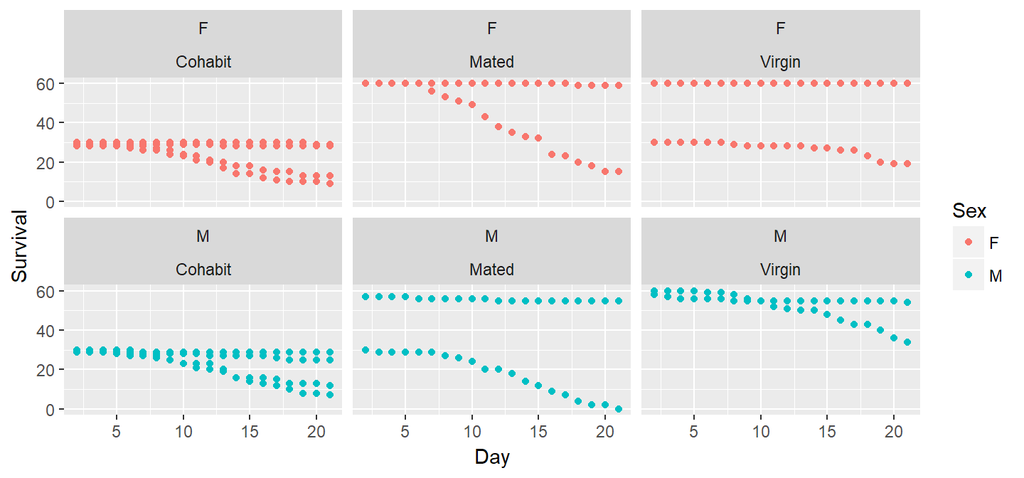

```r
dayplot +
  geom_point(aes(color = Sex)) +
  facet_wrap(Sex ~ Mating_status)
```

## Linear regression

```
##
## Call:
## lm(formula = Survival ~ Day, data = bio_df)
##
## Residuals:
##     Min      1Q  Median      3Q     Max
## -28.185 -12.309  -6.619  17.691  31.815
##
## Coefficients:
##             Estimate Std. Error t value Pr(>|t|)
## (Intercept)  43.7957     2.0006   21.89  < 2e-16 ***
## Day          -0.7434     0.1555   -4.78 2.68e-06 ***
## ---
## Signif. codes:  0 '***' 0.001 '**' 0.01 '*' 0.05 '.' 0.1 ' ' 1
##
## Residual standard error: 16.04 on 318 degrees of freedom
## Multiple R-squared:  0.06704,    Adjusted R-squared:  0.06411
## F-statistic: 22.85 on 1 and 318 DF,  p-value: 2.68e-06
```

We can quickly see that it’s all nonsense

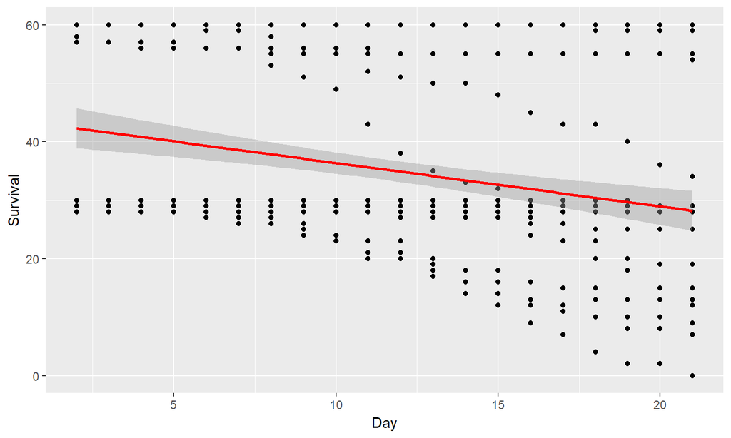